# Relatorio

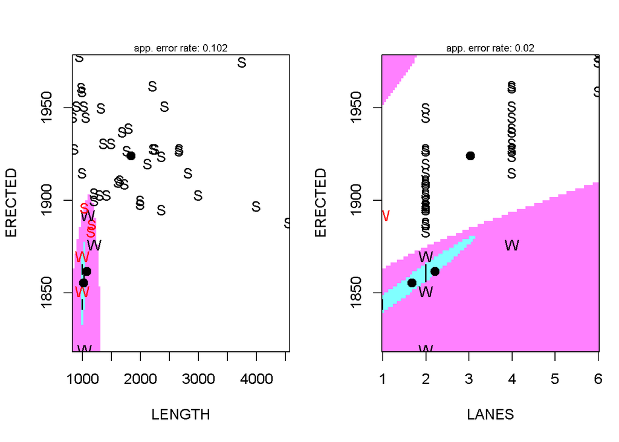

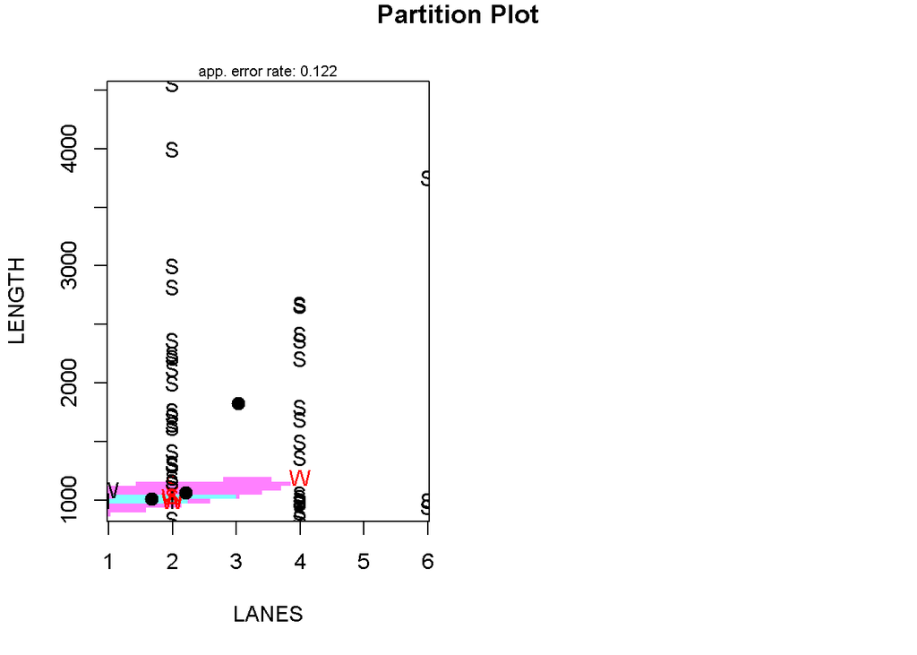

```r
partimat(MATERIAL~., data = training, method="qda")
```

```r
#Confusion matrix and accuracy - training data
p1 <- predict(linear, training)$class
tab <- table(Predicted = p1, Actual = training$MATERIAL)
tab
```

```
##          Actual
## Predicted IRON STEEL WOOD
##     IRON     0     0    0
##     STEEL    0    41    1
##     WOOD     3     0    4
```

```r
#print(paste(“Quantidade prevista (%):”, sum(diag(tab))/sum(tab)*100))

#Confusion matrix and accuracy - testing data
p2 <- predict(linear, testing)$class
tab2 <- table(Predicted = p2, Actual = testing$MATERIAL)
tab2
```

```
##          Actual
## Predicted IRON STEEL WOOD
##     IRON     0     0    0
##     STEEL    0    17    0
##     WOOD     2     0    4
```

```r
#print(paste(“Quantidade prevista (%):”, sum(diag(tab2))/sum(tab2)*100))
```

## Correlação Canônica

A técnica de correlação canônica busca encontrar correlações entre dois conjuntos de variáveis quantitativas. Como nosso conjunto de dados não apresenta variáveis numéricas o suficiente para realizar este tipo de análise, determinamos a técnica como desnecessária.

## Testes de Aderência (Análise de Dados Categorizados)

Para os testes de aderência, tentaremos uma simples hipótese (por falta de alternativas): de que metade das pontes é de aço, e metade não é.

```r
# H_0: a distribuição das pontes é de 50% STEEL, 50% o resto
# H_1: a distribuição não é.
data <- read.csv("data.txt", na.strings="?")
dataSubset <- subset(data, select = c("MATERIAL"))
dataSubset <- dataSubset[complete.cases(dataSubset), ]

observados <- c(length(dataSubset[dataSubset == "STEEL"]), length(dataSubset[dataSubset != "STEEL"]))
p <- c(0.5, 0.5)

chisq.test(x = observados, p=p, simulate.p.value = TRUE)
```

```
##
##  Chi-squared test for given probabilities with simulated p-value
##  (based on 2000 replicates)
##
## data:  observados
## X-squared = 25.509, df = NA, p-value = 0.0004998
```

Como vimos, a probabilidade desses dados se adequarem a probabilidade é muito baixa, menor que o nível de significância comum, de 0.05.

## Co-clustering

```r
library(blockcluster)
data <- read.csv("data.txt", na.strings="?")
dataSubset <- subset(data, select = c("ERECTED", "LENGTH", "LANES"))
dados <- subset(data, select = c("LOCATION","ERECTED","LENGTH","LANES"))
dados <- data.matrix(data)
#usage of cocluster function in its most simplest form
out<-cocluster(dados,datatype="continuous",nbcocluster=c(2,3))
```

```
## Co-Clustering Failed!
```

```r
#Summarize the output results
summary(out)
```

```
## Co-Clustering was not successful.
```

```r
#Plot the original and Co-clustered data
plot(out)
```

```
## Co-Clustering was not successful.
```

Como é possível observar, a partir das variáveis fornecidas, não foi possível montar um cocluster sobre elas, uma vez que são insuficientes para formar agrupamentos independentes. Com isso, é possível afirmar que a técnica de Co-Clustering, para o nosso caso, não é uma técnica útil.

## Random Forest

```r
require(randomForest)
require(MASS)
dataSubset <- read.csv("data.txt", na.strings="?")
dataSubset = subset(dataSubset, select = -IDENTIF)
dados <- dataSubset[complete.cases(dataSubset), ]
attach(dados)
set.seed(101)
dim(dados)
```

```
## [1] 70 12
```

```r
#training Sample with 300 observations

train=sample(1:nrow(dados),40)
?dados  #to search on the dataset
```

```
## No documentation for 'dados' in specified packages and libraries:
## you could try '??dados'
```

```r
dados.rf = randomForest(ERECTED ~ . , data = dados , subset = train)
dados.rf
```

```
##
## Call:
##  randomForest(formula = ERECTED ~ ., data = dados, subset = train)
##                Type of random forest: regression
##                      Number of trees: 500
## No. of variables tried at each split: 3
##
##           Mean of squared residuals: 442.6055
##                     % Var explained: 68.32
```

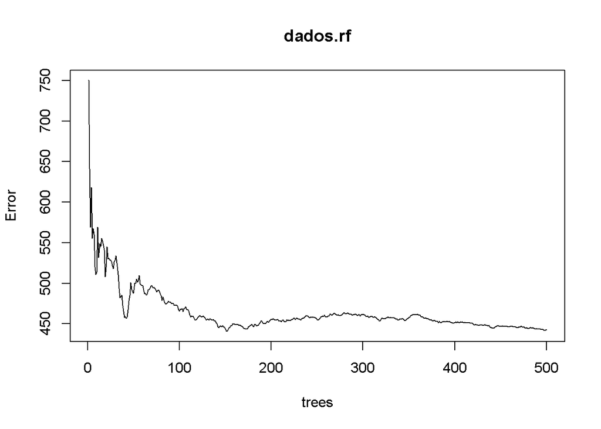

```r
plot(dados.rf)
```

```r
oob.err=double(13)
test.err=double(13)

#mtry is no of Variables randomly chosen at each split
for(mtry in 1:13)
{
  rf=randomForest(ERECTED ~ . , data = dados , subset = train,mtry=mtry,ntree=400)
  oob.err[mtry] = rf$mse[400] #Error of all Trees fitted

  pred<-predict(rf,dados[-train,]) #Predictions on Test Set for each Tree
  test.err[mtry]= with(dados[-train,], mean( (ERECTED - pred)^2)) #Mean Squared Test Error

  cat(mtry," ") #printing the output to the console

}
```

```
## 1  2  3  4  5  6  7  8  9  10  11
```

```
## 12
```

```
## 13
```

```r
test.err
```

```
##  [1] 333.3104 278.5377 283.4597 293.7033 303.6559 330.9361 326.2353
##  [8] 352.9293 374.5773 400.1168 407.8628 373.5440 401.3846
```

```r
oob.err
```

```
##  [1] 559.9731 473.0511 428.9182 433.1040 442.5525 436.9328 435.9690
##  [8] 434.4700 434.1591 431.0906 445.2603 430.7451 464.8649
```

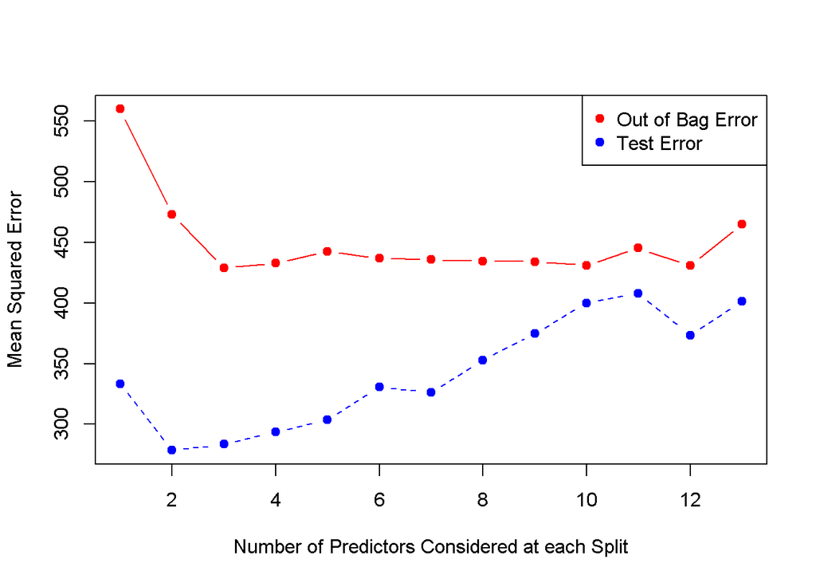

```r
matplot(1:mtry , cbind(oob.err,test.err), pch=19 , col=c("red","blue"),type="b",ylab="Mean Squared Error",xlab="Number of Predictors Considered at each Split")
legend("topright",legend=c("Out of Bag Error","Test Error"),pch=19, col=c("red","blue"))
```